# Week11_final

Разделим выборку снова на две части

```r
set.seed(2)
train=sample(1:nrow(algae), 100)
algae.test <- algae[-train,]
algae.train <- algae[train,]

tree <- ctree(a1 ~ ., data = algae.train)
```

Визуализируем получившееся дерево

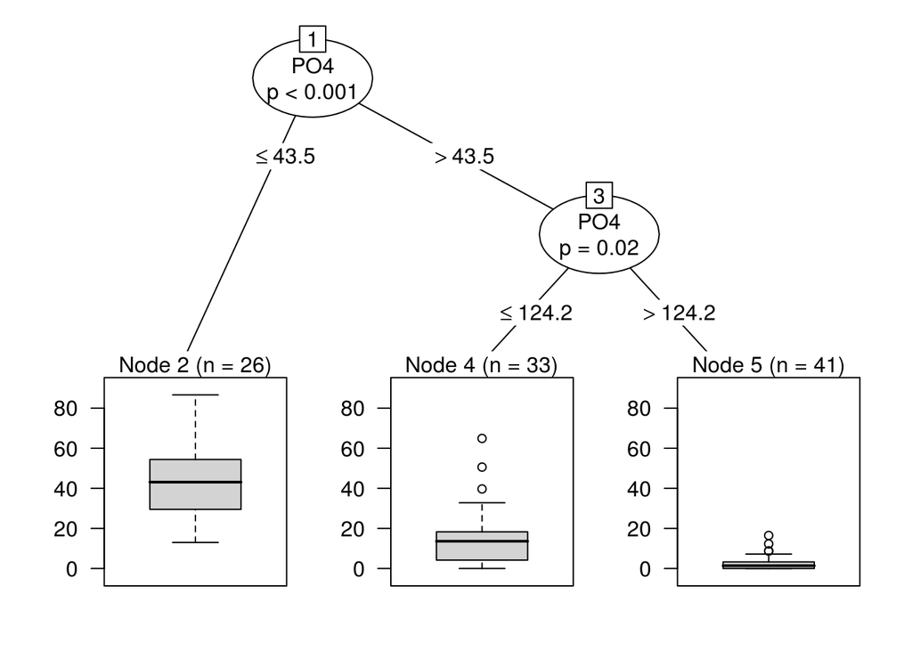

```r
plot(tree)
```

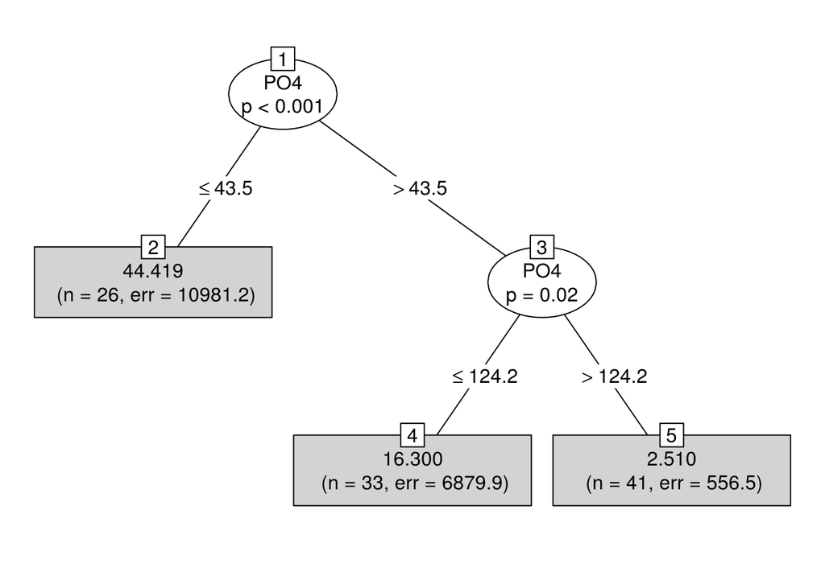

```r
plot(tree, type = "simple")
```

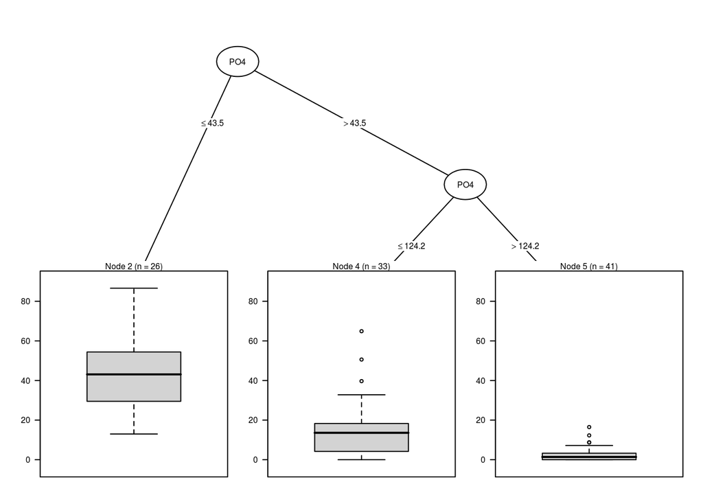

```r
plot(tree, gp = gpar(fontsize = 6),     # font size changed to 6
      inner_panel=node_inner,
      ip_args=list(
        abbreviate = F,
        id = FALSE,
        pval=F)
 )
```

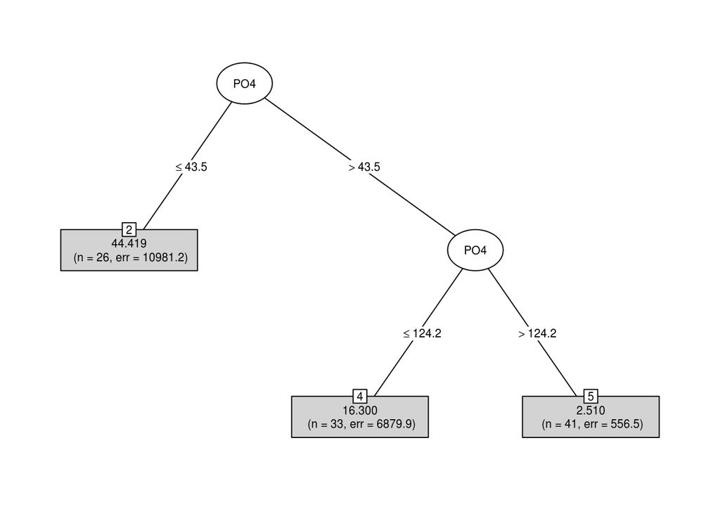

```r
plot(tree, gp = gpar(fontsize = 8),     # font size changed to 8
      inner_panel=node_inner,
      ip_args=list(
        abbreviate = F,
        id = FALSE,
        pval=F),
     type = "simple"
 )
```

```r
tree.pred <- predict(tree, algae.test)
```

Для того чтобы понять насколько наше предсказание отличается от реального значения посчитаем коэффициент детерминации. Коэффициент детерминации (R2) дает предварительную оценку качества модели. Он показывает долю объясненной дисперсии зависимой переменной (доля общей суммы квадратов, объясненной уравнением регрессии).

```r
# residual sum of squares (rss)
rss = sum((tree.pred - algae.test$a1)^2)
# total sum of squares (tss)
tss = sum((mean(algae.test$a1) - algae.test$a1)^2)
# R^2
1-rss/tss
```

```
## [1] 0.2526098
```

R2 принимает значение от 0 до 1, чем ближе R2 к 1, тем лучше модель, тем меньше доля необъяснённого. Наша модель объясняет 25% дисперссии в средней численности водорослей вида а1

Возможные проблемы: Проблемы с использованием R2 заключаются в том, что его значение не уменьшается при добавлении в уравнение факторов, сколь плохи бы они ни были. Он гарантированно будет равен 1, если мы добавим в модель столько факторов, сколько у нас наблюдений. Поэтому сравнивать модели с разным количеством факторов, используя R2, не имеет смысла.

**Доп. материалы:**

В следующей статье анализируются фукции rpart() из пакета rpart и ctree() из пакета party https://www.r-bloggers.com/party-with-the-first-tribe/

http://www.statmethods.net/advstats/cart.html